# DoD Military Community and Family Policy Military OneSource eNewsletter

Paul Testa and Jake Bowers

August 29, 2016

# Setup

- Download “wrkdat.csv” onto local machine in the data subdirectory
- Load files and libaries

```r
wrkdat <- read.csv("data/wrkdat.csv", as.is = TRUE)
```

The outcome is whether or not a member of the experimental pool subscribed to the newsletter. We currently assume that all members of the experimental pool who have a 0 for subscribed did not subscribe under a different name and email address. We return to scrutinize the effect of this assumption later.

```r
# Subscribed is the primary outcome
table(wrkdat$subscribed, exclude = c())
```

```
     0      1   <NA>
485297   6582      0
```

```r
## Make some variables into factors for contingency table analysis
wrkdat$batchday2F <- factor(wrkdat$batchday2)
wrkdat$treatmentF <- factor(wrkdat$treatment)
wrkdat$subscribedF <- factor(wrkdat$subscribed)
```

Overall, we the active choices were better than the opt in:

```r
wrkdat$active <- ifelse(wrkdat$treatment %in% c("F", "D", "B"), 1, 0)
prop.table(with(wrkdat, table(active, subscribed)), margin = 1)
```

```
      subscribed
active       0       1
     0 0.98749 0.01251
     1 0.98574 0.01426
```

```r
wrkdat$short <- ifelse(wrkdat$treatment %in% c("F", "E"), 1, 0)
prop.table(with(wrkdat, table(short, subscribed)), margin = 1)
```

```
     subscribed
short       0       1
    0 0.98711 0.01289
    1 0.98563 0.01437
```

# Test for any difference across treatments

Because the experiment was randomized by batch, and because of trouble matching subscribers uniquely to the experimental pool, we analyze the data by a collapsed version of the 82 batch indicators that we call `batchday`. Nearly all batches were sent 2 per day and the subscriber data only has day of subscription, not hour or minute. This choice, to make new experimental blocks from the original ones will decrease statistical power, but, because the blocks were basically the same size, and because we take blocking into account when we calculate estimates, our estimates will be unbiased.

Do we have enough information to reject the claim that there are no differences between the treatments? We use the generalized Cochran-Mantel-Haensel test to address this question. We are using the coin library because it allows for easy assessment of this test without large sample assumptions by simulating from the reference distribution implied by the experiment itself.

```r
library(coin)

cmh1approx <- cmh_test(subscribedF ~ treatmentF | batchday2F, data = wrkdat, distribution = approximate(B = 1000))
cmh1 <- cmh_test(subscribedF ~ treatmentF | batchday2F, data = wrkdat)

bigtab <- with(wrkdat, table(treatmentF, subscribed, batchday2F))
cmh2 <- mantelhaen.test(bigtab)

c(pvalue(cmh1), pvalue(cmh1approx)[[1]], cmh2$p.value)
```

```
[1] 0.000000000003556 0.000000000000000 0.000000000003556
```

Those $p$-values indicate that there is a lot of evidence against the idea that all six emails had the same effect and, despite the rareness of the outcome, the substantive interpretation of the test is the same whether or not we rely on large sample assumptions or sample directly from the randomization distribution.

# Estimation and Inference for Difference of Proportions

Now we’ll start to draw comparisons between specific treatments and groups of treatments.

In the figure below we show the proportions subscribing in each treatment group with 95-percent confidence intervals. Treatments B and F appear to be the most successful at encouraging subscription to the newsletter. Because treatment was assigne by block, our overall estimates of proportions are weighted by the size of the block. Here, we follow @lin2013agnostic and the [Green Lab Standard Operating Procedure](https://github.com/acoppock/Green-Lab-SOP) calculating these quantities.

Block randomized experiments require that the estimand be defined with respect to a scheme for weighting the contributions of the different block-specific estimates, and an estimator which is unbiased (or at least consistent) for that estimand. In this case, we have two possible estimands: When block sizes vary and especially when the proportion treated per block varies greatly, one can substantially increase precision by estimating using what are known as harmonic weights. In this case, with more or less equal sized blocks (40 out of 41 are equal), and more or less equal proportions, we use the simple block size weighting because the proportions themselves are easier to interpret in such a case.

We will want to produce confidence intervals and test hypotheses about the difference proportions, and Lin (2011,2013) shows that one can use a least squares model to estimate block size weighted differences of proportions and also that the design-based standard errors (and p-values and confidence intervals) can be directly calculated using the HC2 standard errors (heteroskedasticity consistent type 2 standard errors).

Not shown: Test that we can recover block size weighted quantites from least squares using a subset of the data.

```
            (Intercept)             treatmentFB             treatmentFC             treatmentFD
               0.009667                0.005000                0.001833                0.003500
            treatmentFE             treatmentFF             batchday2F2             batchday2F3
               0.002167                0.004167                0.007500                0.006500
treatmentFB:batchday2F2 treatmentFC:batchday2F2
              -0.005000               -0.006500
```

```
 treatmentA treatmentFB treatmentFC treatmentFD treatmentFE treatmentFF
   0.009667    0.014667    0.011500    0.013167    0.011833    0.013833
```

```
       A        B        C        D        E        F
0.009667 0.014667 0.011500 0.013167 0.011833 0.013833
```

```r
## Batch size weighting

## First calculate using a function that does the weighting directly
realtaus <- tausbyhand(dat = wrkdat, block = "batchday2F", treatment = "treatmentF", outcome = "subscribed")

## Now try this using lm()
prop_b <- table(wrkdat$batchday2F)/nrow(wrkdat)
B <- model.matrix(~batchday2F + 0, data = wrkdat)
Bmd <- sapply(1:ncol(B), function(i) {
    B[, i] - prop_b[i]
})
colnames(Bmd) <- colnames(B)
wrkdat[, colnames(Bmd)] <- Bmd

bigfmla <- as.formula(paste("subscribed~treatmentF*(", paste(colnames(Bmd)[-1], collapse = "+"), ")"))

lm2 <- lm(bigfmla, data = wrkdat)
coef(lm2)[1:10]
```

```
(Intercept) treatmentFB treatmentFC treatmentFD treatmentFE treatmentFF batchday2F2 batchday2F3
  0.0127348   0.0015248  -0.0008783  -0.0000366   0.0001952   0.0030741   0.0075000   0.0065000
batchday2F4 batchday2F5
  0.0090000   0.0110000
```

```r
estprops <- c(treatmentA = coef(lm2)[[1]], coef(lm2)[1] + coef(lm2)[2:6])
stopifnot(all.equal(realtaus, estprops, check.attributes = FALSE))
## This next shows that we can get the same answers as suggested by Lin if we don't exclude a level of
## treatment.
lm3 <- lm(update(bigfmla, . ~ +batchday2F1 - 1 + .), data = wrkdat)
lm3props <- coef(lm3)[grep("treatment.[A-F]$", names(coef(lm3)))]
stopifnot(all(abs(lm3props - estprops) < 0.0000000001))
lm3props
```

```
treatmentFA treatmentFB treatmentFC treatmentFD treatmentFE treatmentFF
    0.01273     0.01426     0.01186     0.01270     0.01293     0.01581
```

Under the assumption that all unmatchable subscribers were not a part of the experiment, we would say that Treatment F was the most powerful, although, the estimated proportions of subscribers are quite low (on the order of 1 to 2 percentage points). Can we distinguish these proportions from 0?

We get the CIs using the HC2 based standard errors following the development in Lin 2011 etc.

```r
library(sandwich)
library(lmtest)
source("confintHC.R")  ## our own CI maker with HC SEs
theCIs <- confint(lm3, parm = names(lm3props), vcov = vcovHC(lm3, type = "HC2"))
```

We show these results in the following graph:

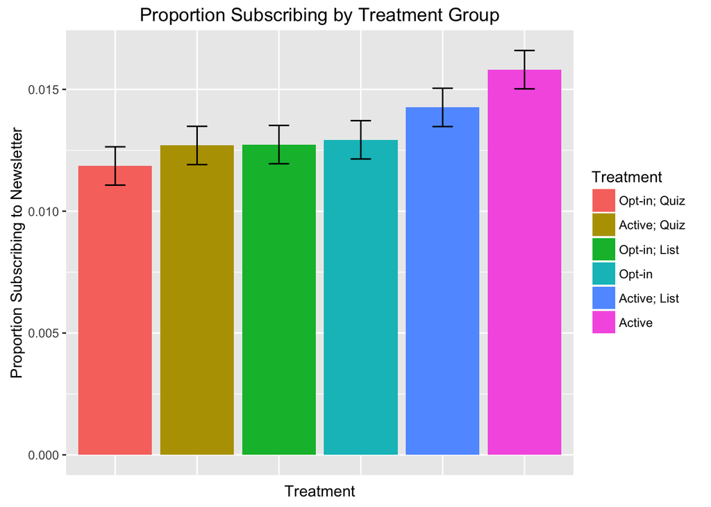

# Test pairwise differences of treatments

This study is clearly big enough to distinguish the effects of any one of the treatments from 0. How do the treatments compare to each other? Next we provide a more formal assessment of the 15 pairwise comparisons by conducting a Tukey Honest Signficant Differences test on an ANOVA model weighted by the size of each batch, with family-wise confidence intervals that reflect the fact that we are making multiple comparisons.

```r
# Anova weighted by size of batch
a1 <- aov(formula(lm3), wrkdat)
coef(a1)[names(lm3props)]
```

```
treatmentFA treatmentFB treatmentFC treatmentFD treatmentFE treatmentFF
    0.01273     0.01426     0.01186     0.01270     0.01293     0.01581
```

```r
thsda1 <- TukeyHSD(a1, which = "treatmentF")
```

We see from the next figure that 5 out of the 15 pairwise comparisons are statistically distinguishable from 0 ($p<0.05$). Specifically, the effects for Treatment F are significantly larger than any other treatment except Treatment B — and there the 95% confidence interval just barely includes 0. The effect for Treatment B, although larger than the remaining Treatments (A,C,D and E) is only distinguishable from Treatment C.

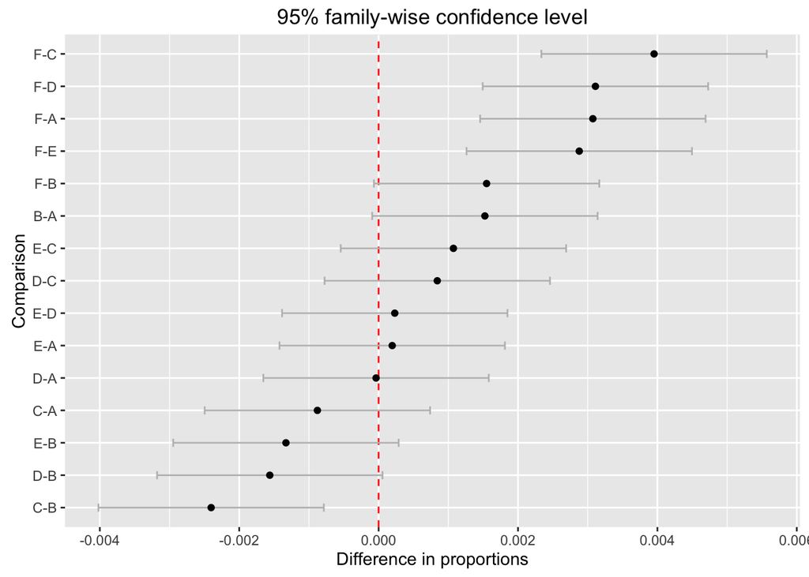

```r
# Get estimates and intervals
tukey <- data.frame(thsda1$treatmentF)
## plot(TukeyHSD(a1))
tukey$Comparison <- factor(rownames(tukey), levels = rev(rownames(tukey)))
tukey$Comparison <- factor(tukey$Comparison, levels = tukey$Comparison[order(tukey$diff)])

p.tukey <- ggplot(tukey, aes(y = Comparison, x = diff)) + geom_vline(xintercept = 0, linetype = 2, col = "red") +
    geom_errorbarh(aes(xmin = lwr, xmax = upr), height = 0.25, col = "grey") + geom_point() + labs(x = "Difference in proportions",
    title = "95% family-wise confidence level")
p.tukey
```

# Test differences in the prespecified subgroups of treatments

This section makes the following comparisons:

- A,C,E versus B,D,F (a test of opt-in versus enhanced active).
- A,B,C,D versus E,F (a test of Block of 10 present versus absent)
- A,B versus C,D (a test of list versus quiz format)

To make life easier, we’ll create indicators of these groupings, write a function to conduct generalized Cochran-Mantel-Haensel tests of these differences, accounting for batch[^1]

```r
# A,C,E versus B,D,F (a test of opt-in versus enhanced active).
wrkdat$treat_bdf_01 <- as.numeric(grepl("B|D|F", wrkdat$treatment))
wrkdat$treat_bdf <- factor(ifelse(grepl("B|D|F", wrkdat$treatment), "Enhanced Active", "Opt-In"))
table(wrkdat$treat_bdf)
```

```
Enhanced Active          Opt-In
         245939          245940
```

```r
# A,B,C,D versus E,F (a test of Block of 10 present versus active)
wrkdat$treat_abcd_01 <- as.numeric(grepl("A|B|C|D", wrkdat$treatment))
wrkdat$treat_abcd <- ifelse(grepl("A|B|C|D", wrkdat$treatment), "Present", "Absent")
wrkdat$treat_abcd <- factor(wrkdat$treat_abcd, levels = c("Present", "Absent"))

# A,B versus C,D (a test of list versus quiz format)
wrkdat$treat_ab_01 <- as.numeric(grepl("A|B", wrkdat$treatment))
wrkdat$treat_ab_01[!grepl("A|B|C|D", wrkdat$treatment)] <- NA
wrkdat$treat_ab <- factor(ifelse(wrkdat$treat_ab_01 == 1, "List", "Quiz"))
```

## Overall table

The following table repeats and collects the results from above.

```r
taball <- table.maker(wrkdat$treatmentF, xnm = "treatmentF", ynm = "subscribed", reflevel = "F")
kable(taball, caption = "All Treatments")
```

All Treatments

|  | **F** | **A** | **B** | **C** | **D** | **E** |
| --- | --- | --- | --- | --- | --- | --- |
| **Sample** | 81979 | 81980 | 81980 | 81980 | 81980 | 81980 |
| Not Subscribed | 80683 | 80936 | 80811 | 81008 | 80939 | 80920 |
| Subscribed | 1296 | 1044 | 1169 | 972 | 1041 | 1060 |
| Proportion Subscribing | 0.0158 | 0.0127 | 0.0143 | 0.0119 | 0.0127 | 0.0129 |
| ___ |  |  |  |  |  |  |
| Difference in Proportions from F |  | -0.0031 | -0.0015 | -0.0040 | -0.0031 | -0.0029 |
| pval for H0: No Diff |  | 0.0000 | 0.0099 | 0.0000 | 0.0000 | 0.0000 |
| 95% CI for Diff |  | -0.0042 | -0.0027 | -0.0051 | -0.0043 | -0.004 |
| 95% CI for Diff |  | -0.0019 | -0.0004 | -0.0028 | -0.002 | -0.0017 |
| ___ |  |  |  |  |  |  |
| Asymp CMH Test | 62.5802 | 0.0000 |  |  |  |  |
| Approx CMH Test | 62.5802 | 0.0000 |  |  |  |  |
| Common Odds Ratio | NA | [NA; NA] |  |  |  |  |

## A,C,E versus B,D,F (a test of opt-in versus enhanced active).

The proportion subscribing among the enhanced active treatments was higher than the proportion among the opt-in treatments (not surprising from the perspective of past literature).

```r
tab_bdf <- table.maker(wrkdat$treat_bdf, xnm = "treat_bdf", ynm = "subscribed")
kable(tab_bdf, caption = "Enhanced Active versus Single Opt-In")
```

Enhanced Active versus Single Opt-In

|  | **Enhanced Active** | **Opt-In** |
| --- | --- | --- |
| **Sample** | 245939 | 245940 |
| Not Subscribed | 242433 | 242864 |
| Subscribed | 3506 | 3076 |
| Proportion Subscribing | 0.0143 | 0.0125 |
| ___ |  |  |
| Difference in Proportions from Enhanced Active |  | -0.0017 |
| pval for H0: No Diff |  | 0.0000 |
| 95% CI for Diff |  | -0.0024 |
| 95% CI for Diff |  | -0.0011 |
| ___ |  |  |
| Asymp CMH Test | 28.3432 | 0.0000 |
| Approx CMH Test | 28.4755 | 0.0000 |
| Common Odds Ratio | 0.8758 | [0.834; 0.92] |

## A,B,C,D versus E,F (a test of Block of 10 present versus active)

Treatments E and F encouraged more subscriptions than A,B,C, or D as a group.

```r
## A,B,C,D versus E,F (a test of Block of 10 present versus active)

tab_abcd <- table.maker(wrkdat$treat_abcd, xnm = "treat_abcd", ynm = "subscribed")
kable(tab_abcd, caption = "Block of 10 Present or Absent")
```

Block of 10 Present or Absent

|  | **Present** | **Absent** |
| --- | --- | --- |
| **Sample** | 327920 | 163959 |
| Not Subscribed | 323694 | 161603 |
| Subscribed | 4226 | 2356 |
| Proportion Subscribing | 0.0129 | 0.0144 |
| ___ |  |  |
| Difference in Proportions from Present |  | 0.0015 |
| pval for H0: No Diff |  | 0.0000 |
| 95% CI for Diff |  | 0.0008 |
| 95% CI for Diff |  | 0.0022 |
| ___ |  |  |
| Asymp CMH Test | 18.0765 | 0.0000 |
| Approx CMH Test | 18.1886 | 0.0000 |
| Common Odds Ratio | 1.1167 | [1.061; 1.175] |

## A,B versus C,D (a test of list versus quiz format)

The list format appears more effective than the quiz format.

```r
# A,B versus C,D (a test of list versus quiz format)
tab_ab <- table.maker(wrkdat$treat_ab, xnm = "treat_ab", ynm = "subscribed")
kable(tab_ab, caption = "List versus Quiz Format")
```

List versus Quiz Format

|  | **List** | **Quiz** |
| --- | --- | --- |
| **Sample** | 163960 | 163960 |
| Not Subscribed | 161747 | 161947 |
| Subscribed | 2213 | 2013 |
| Proportion Subscribing | 0.0135 | 0.0123 |
| ___ |  |  |
| Difference in Proportions from List |  | -0.0012 |
| pval for H0: No Diff |  | 0.0020 |
| 95% CI for Diff |  | -0.002 |
| 95% CI for Diff |  | -0.0004 |
| ___ |  |  |
| Asymp CMH Test | 9.4932 | 0.0021 |
| Approx CMH Test | 9.5889 | 0.0020 |
| Common Odds Ratio | 0.9085 | [0.855; 0.965] |

# Assess sensitivity of the results to different ways of distributing unmatched cases

The table below shows the number of unmatched cases by batch day in the list of subscribers (i.e. people shown as suscribing who we were unable to match to the experimental pool by either email, full name, or last name).

```r
# List of unmatchables by batch day The count comes from a table that we created using the
# subscribers data and posted to github
unmatchables <- data.frame(batchday2 = sort(unique(wrkdat$batchday2)), count = c(24, 6, 14, 33, 20, 24,
    19, 38, 8, 18, 8, 99, 14, 23, 20, 48, 16, 12, 22, 44, 16, 53, 12, 26, 40, 13, 64, 23, 54, 24, 29,
    15, 52, 10, 11, 65, 22, 25, 40, 10, 81))

tab_unmatch <- unmatchables
colnames(tab_unmatch) <- c("Batch", "Unmatched Cases")
kable(tab_unmatch, caption = "Unmatched cases by batch")
```

Unmatched cases by batch

| Batch | Unmatched Cases |
| --- | --- |
| 1 | 24 |
| 2 | 6 |
| 3 | 14 |
| 4 | 33 |
| 5 | 20 |
| 6 | 24 |
| 7 | 19 |
| 8 | 38 |
| 9 | 8 |
| 10 | 18 |
| 11 | 8 |
| 12 | 99 |
| 13 | 14 |
| 14 | 23 |
| 15 | 20 |
| 16 | 48 |
| 17 | 16 |
| 18 | 12 |
| 19 | 22 |
| 20 | 44 |
| 21 | 16 |
| 22 | 53 |
| 23 | 12 |
| 24 | 26 |
| 25 | 40 |
| 26 | 13 |
| 27 | 64 |
| 28 | 23 |
| 29 | 54 |
| 30 | 24 |
| 31 | 29 |
| 32 | 15 |
| 33 | 52 |
| 34 | 10 |
| 35 | 11 |
| 36 | 65 |
| 37 | 22 |
| 38 | 25 |
| 39 | 40 |
| 40 | 10 |
| 41 | 81 |

It is possible that these unmatched cases represent successful interventions (i.e. people who subscribed to the newsletter because of the emails but who did not provide the same name or email address), it is also possible that they reflect subscriptions by people who were not a part of the experimental pool (and so should be ignored, in essence, we are assuming that this is the case in the preceding analyses). In this section, we assess the consequences of that assumption through a series of simulations that ask what would our results look like had we been able to match these subscribers to members of the experimental pool.

To set bounds on our results we examine the results from assigning all 1,195 unmatched cases to each of the six treatment conditions, while respecting the distribution of unmatched cases by batch. (Code not shown.)

```
[1] 0.01458
```

```
                 treatmentF    A    B    C    D    E    F
subscribed yallA
0          0                1966 1970 1977 1977 1977 1981
           1                  24    0    0    0    0    0
1          0                   0    0    0    0    0    0
           1                  10   30   23   23   23   19
```

```
           treatmentF    A    B    C    D    E    F
subscribed
0                     1990 1970 1977 1977 1977 1981
1                       10   30   23   23   23   19
```

Now, we re-calculate the p-values for the overall test distinguishing the treatments from each other. And we also present the different estimates of proportions and their associated CIs.

First, we see that even under the extreme scenarios that we consider (all unmatched subscribers assigned to only one treatment group), we can still distinguish the effects of the different treatment groups.

```r
extremeoutcomesF <- paste(extremeoutcomes, "F", sep = "")

cmhps <- sapply(extremeoutcomesF, function(y) {
    f <- reformulate(paste("treatmentF", "|batchday2F"), response = y)
    # CMH Test, use asymptotic results for now for now
    cmh <- cmh_test(f, data = wrkdat)
    pvalue(cmh)
})

cmhps
```

```
yallAF yallBF yallCF yallDF yallEF yallFF
     0      0      0      0      0      0
```

These tests show that, across the ways that subscription are asssigned (all to Treatment A, all to B, etc…), we can always distinguish the effects of the treatments from each other.

## The winning treatment depends on our assumption of no non-pool subscribers

Below we show that, if all unmatched subscribers came from any one treatment arm, that our results would change: whichever arm receives those subscribers is the winning treatment. We are sure that the actual results, should we be able to know which subscribers came from outside the experiment and which subscribers matched to which row in the experimental pool, would be less extreme than this. However, we do not know how much less extreme.

Now we show how the proportions subscribing in each treatment group might differ.

```r
tabAllA <- table.maker(wrkdat$treatmentF, xnm = "treatmentF", ynm = "yallA", reflevel = "F")
kable(tabAllA, caption = "If all the missing subcribers were in treatment A")
```

If all the missing subcribers were in treatment A

|  | **F** | **A** | **B** | **C** | **D** | **E** |
| --- | --- | --- | --- | --- | --- | --- |
| **Sample** | 81979 | 81980 | 81980 | 81980 | 81980 | 81980 |
| Not Subscribed | 80683 | 79741 | 80811 | 81008 | 80939 | 80920 |
| Subscribed | 1296 | 2239 | 1169 | 972 | 1041 | 1060 |
| Proportion Subscribing | 0.0158 | 0.0273 | 0.0143 | 0.0119 | 0.0127 | 0.0129 |
| ___ |  |  |  |  |  |  |
| Difference in Proportions from F |  | 0.0115 | -0.0015 | -0.0040 | -0.0031 | -0.0029 |
| pval for H0: No Diff |  | 0.0000 | 0.0099 | 0.0000 | 0.0000 | 0.0000 |
| 95% CI for Diff |  | 0.0101 | -0.0027 | -0.0051 | -0.0043 | -0.004 |
| 95% CI for Diff |  | 0.0129 | -0.0004 | -0.0028 | -0.002 | -0.0017 |
| ___ |  |  |  |  |  |  |
| Asymp CMH Test | 886.8871 | 0.0000 |  |  |  |  |
| Approx CMH Test | 886.8871 | 0.0000 |  |  |  |  |
| Common Odds Ratio | NA | [NA; NA] |  |  |  |  |

```r
tabAllB <- table.maker(wrkdat$treatmentF, xnm = "treatmentF", ynm = "yallB", reflevel = "F")
kable(tabAllB, caption = "If all the missing subcribers were in treatment B")
```

If all the missing subcribers were in treatment B

|  | **F** | **A** | **B** | **C** | **D** | **E** |
| --- | --- | --- | --- | --- | --- | --- |
| **Sample** | 81979 | 81980 | 81980 | 81980 | 81980 | 81980 |
| Not Subscribed | 80683 | 80936 | 79616 | 81008 | 80939 | 80920 |
| Subscribed | 1296 | 1044 | 2364 | 972 | 1041 | 1060 |
| Proportion Subscribing | 0.0158 | 0.0127 | 0.0288 | 0.0119 | 0.0127 | 0.0129 |
| ___ |  |  |  |  |  |  |
| Difference in Proportions from F |  | -0.0031 | 0.0130 | -0.0040 | -0.0031 | -0.0029 |
| pval for H0: No Diff |  | 0.0000 | 0.0000 | 0.0000 | 0.0000 | 0.0000 |
| 95% CI for Diff |  | -0.0042 | 0.0116 | -0.0051 | -0.0043 | -0.004 |
| 95% CI for Diff |  | -0.0019 | 0.0145 | -0.0028 | -0.002 | -0.0017 |
| ___ |  |  |  |  |  |  |
| Asymp CMH Test | 1121.1399 | 0.0000 |  |  |  |  |
| Approx CMH Test | 1121.1399 | 0.0000 |  |  |  |  |
| Common Odds Ratio | NA | [NA; NA] |  |  |  |  |

```r
tabAllC <- table.maker(wrkdat$treatmentF, xnm = "treatmentF", ynm = "yallC", reflevel = "F")
kable(tabAllC, caption = "If all the missing subcribers were in treatment C")
```

If all the missing subcribers were in treatment C

|  | **F** | **A** | **B** | **C** | **D** | **E** |
| --- | --- | --- | --- | --- | --- | --- |
| **Sample** | 81979 | 81980 | 81980 | 81980 | 81980 | 81980 |
| Not Subscribed | 80683 | 80936 | 80811 | 79813 | 80939 | 80920 |
| Subscribed | 1296 | 1044 | 1169 | 2167 | 1041 | 1060 |
| Proportion Subscribing | 0.0158 | 0.0127 | 0.0143 | 0.0264 | 0.0127 | 0.0129 |
| ___ |  |  |  |  |  |  |
| Difference in Proportions from F |  | -0.0031 | -0.0015 | 0.0106 | -0.0031 | -0.0029 |
| pval for H0: No Diff |  | 0.0000 | 0.0099 | 0.0000 | 0.0000 | 0.0000 |
| 95% CI for Diff |  | -0.0042 | -0.0027 | 0.0092 | -0.0043 | -0.004 |
| 95% CI for Diff |  | -0.0019 | -0.0004 | 0.012 | -0.002 | -0.0017 |
| ___ |  |  |  |  |  |  |
| Asymp CMH Test | 751.9574 | 0.0000 |  |  |  |  |
| Approx CMH Test | 751.9574 | 0.0000 |  |  |  |  |
| Common Odds Ratio | NA | [NA; NA] |  |  |  |  |

```r
tabAllD <- table.maker(wrkdat$treatmentF, xnm = "treatmentF", ynm = "yallD", reflevel = "F")
kable(tabAllD, caption = "If all the missing subcribers were in treatment D")
```

If all the missing subcribers were in treatment D

|  | **F** | **A** | **B** | **C** | **D** | **E** |
| --- | --- | --- | --- | --- | --- | --- |
| **Sample** | 81979 | 81980 | 81980 | 81980 | 81980 | 81980 |
| Not Subscribed | 80683 | 80936 | 80811 | 81008 | 79744 | 80920 |
| Subscribed | 1296 | 1044 | 1169 | 972 | 2236 | 1060 |
| Proportion Subscribing | 0.0158 | 0.0127 | 0.0143 | 0.0119 | 0.0273 | 0.0129 |
| ___ |  |  |  |  |  |  |
| Difference in Proportions from F |  | -0.0031 | -0.0015 | -0.0040 | 0.0115 | -0.0029 |
| pval for H0: No Diff |  | 0.0000 | 0.0099 | 0.0000 | 0.0000 | 0.0000 |
| 95% CI for Diff |  | -0.0042 | -0.0027 | -0.0051 | 0.0101 | -0.004 |
| 95% CI for Diff |  | -0.0019 | -0.0004 | -0.0028 | 0.0129 | -0.0017 |
| ___ |  |  |  |  |  |  |
| Asymp CMH Test | 881.2650 | 0.0000 |  |  |  |  |
| Approx CMH Test | 881.2650 | 0.0000 |  |  |  |  |
| Common Odds Ratio | NA | [NA; NA] |  |  |  |  |

```r
tabAllE <- table.maker(wrkdat$treatmentF, xnm = "treatmentF", ynm = "yallE", reflevel = "F")
kable(tabAllE, caption = "If all the missing subcribers were in treatment E")
```

If all the missing subcribers were in treatment E

|  | **F** | **A** | **B** | **C** | **D** | **E** |
| --- | --- | --- | --- | --- | --- | --- |
| **Sample** | 81979 | 81980 | 81980 | 81980 | 81980 | 81980 |
| Not Subscribed | 80683 | 80936 | 80811 | 81008 | 80939 | 79725 |
| Subscribed | 1296 | 1044 | 1169 | 972 | 1041 | 2255 |
| Proportion Subscribing | 0.0158 | 0.0127 | 0.0143 | 0.0119 | 0.0127 | 0.0275 |
| ___ |  |  |  |  |  |  |
| Difference in Proportions from F |  | -0.0031 | -0.0015 | -0.0040 | -0.0031 | 0.0117 |
| pval for H0: No Diff |  | 0.0000 | 0.0099 | 0.0000 | 0.0000 | 0.0000 |
| 95% CI for Diff |  | -0.0042 | -0.0027 | -0.0051 | -0.0043 | 0.0103 |
| 95% CI for Diff |  | -0.0019 | -0.0004 | -0.0028 | -0.002 | 0.0131 |
| ___ |  |  |  |  |  |  |
| Asymp CMH Test | 916.8714 | 0.0000 |  |  |  |  |
| Approx CMH Test | 916.8714 | 0.0000 |  |  |  |  |
| Common Odds Ratio | NA | [NA; NA] |  |  |  |  |

```r
tabAllF <- table.maker(wrkdat$treatmentF, xnm = "treatmentF", ynm = "yallF", reflevel = "F")
kable(tabAllF, caption = "If all the missing subcribers were in treatment F")
```

If all the missing subcribers were in treatment F

|  | **F** | **A** | **B** | **C** | **D** | **E** |
| --- | --- | --- | --- | --- | --- | --- |
| **Sample** | 81979 | 81980 | 81980 | 81980 | 81980 | 81980 |
| Not Subscribed | 79488 | 80936 | 80811 | 81008 | 80939 | 80920 |
| Subscribed | 2491 | 1044 | 1169 | 972 | 1041 | 1060 |
| Proportion Subscribing | 0.0304 | 0.0127 | 0.0143 | 0.0119 | 0.0127 | 0.0129 |
| ___ |  |  |  |  |  |  |
| Difference in Proportions from F |  | -0.0177 | -0.0161 | -0.0185 | -0.0177 | -0.0175 |
| pval for H0: No Diff |  | 0.0000 | 0.0000 | 0.0000 | 0.0000 | 0.0000 |
| 95% CI for Diff |  | -0.0191 | -0.0176 | -0.0199 | -0.0191 | -0.0189 |
| 95% CI for Diff |  | -0.0162 | -0.0147 | -0.0171 | -0.0163 | -0.0161 |
| ___ |  |  |  |  |  |  |
| Asymp CMH Test | 1359.1961 | 0.0000 |  |  |  |  |
| Approx CMH Test | 1359.1961 | 0.0000 |  |  |  |  |
| Common Odds Ratio | NA | [NA; NA] |  |  |  |  |

# Code Appendix

```r
wrkdat <- read.csv("data/wrkdat.csv", as.is = TRUE)
# Subscribed is the primary outcome
table(wrkdat$subscribed, exclude = c())
## Make some variables into factors for contingency table analysis
wrkdat$batchday2F <- factor(wrkdat$batchday2)
wrkdat$treatmentF <- factor(wrkdat$treatment)
wrkdat$subscribedF <- factor(wrkdat$subscribed)
library(coin)

cmh1approx <- cmh_test(subscribedF ~ treatmentF | batchday2F, data = wrkdat, distribution = approximate(B = 1000))
cmh1 <- cmh_test(subscribedF ~ treatmentF | batchday2F, data = wrkdat)

bigtab <- with(wrkdat, table(treatmentF, subscribed, batchday2F))
cmh2 <- mantelhaen.test(bigtab)

c(pvalue(cmh1), pvalue(cmh1approx)[[1]], cmh2$p.value)
theprops <- data.frame(estprops, theCIs)
# Add names and Treatment indicator
colnames(theprops) <- c("pbar", "ll", "ul")
row.names(theprops) <- c("A", "B", "C", "D", "E", "F")
theprops$Treatment <- c("Opt-in; List", "Active; List", "Opt-in; Quiz", "Active; Quiz", "Opt-in", "Active")
theprops$Treatment <- factor(theprops$Treatment, levels = theprops$Treatment[order(theprops$pbar)])

# Plot with ggplot2 library(ggplot2)
dodge <- position_dodge(width = 0.9)
p.props <- ggplot(theprops, aes(Treatment, pbar, fill = Treatment)) + geom_bar(stat = "identity", position = dodge) +
    geom_errorbar(aes(ymin = ll, ymax = ul), position = dodge, width = 0.25) + labs(list(y = "Proportion Subscribing to Newsletter",
    title = "Proportion Subscribing by Treatment Group")) + theme(axis.text.x = element_blank(), axis.ticks.x = element_blank())
p.props

# Get estimates and intervals
tukey <- data.frame(thsda1$treatmentF)
## plot(TukeyHSD(a1))
tukey$Comparison <- factor(rownames(tukey), levels = rev(rownames(tukey)))
tukey$Comparison <- factor(tukey$Comparison, levels = tukey$Comparison[order(tukey$diff)])

p.tukey <- ggplot(tukey, aes(y = Comparison, x = diff)) + geom_vline(xintercept = 0, linetype = 2, col = "red") +
    geom_errorbarh(aes(xmin = lwr, xmax = upr), height = 0.25, col = "grey") + geom_point() + labs(x = "Difference in proportions",
    title = "95% family-wise confidence level")
p.tukey
# A,C,E versus B,D,F (a test of opt-in versus enhanced active).
wrkdat$treat_bdf_01 <- as.numeric(grepl("B|D|F", wrkdat$treatment))
wrkdat$treat_bdf <- factor(ifelse(grepl("B|D|F", wrkdat$treatment), "Enhanced Active", "Opt-In"))
table(wrkdat$treat_bdf)
# A,B,C,D versus E,F (a test of Block of 10 present versus active)
wrkdat$treat_abcd_01 <- as.numeric(grepl("A|B|C|D", wrkdat$treatment))
wrkdat$treat_abcd <- ifelse(grepl("A|B|C|D", wrkdat$treatment), "Present", "Absent")
wrkdat$treat_abcd <- factor(wrkdat$treat_abcd, levels = c("Present", "Absent"))

# A,B versus C,D (a test of list versus quiz format)
wrkdat$treat_ab_01 <- as.numeric(grepl("A|B", wrkdat$treatment))
wrkdat$treat_ab_01[!grepl("A|B|C|D", wrkdat$treatment)] <- NA
wrkdat$treat_ab <- factor(ifelse(wrkdat$treat_ab_01 == 1, "List", "Quiz"))

tab_bdf <- table.maker(wrkdat$treat_bdf, xnm = "treat_bdf", ynm = "subscribed")
kable(tab_bdf, caption = "Enhanced Active versus Single Opt-In")
## A,B,C,D versus E,F (a test of Block of 10 present versus active)

tab_abcd <- table.maker(wrkdat$treat_abcd, xnm = "treat_abcd", ynm = "subscribed")
kable(tab_abcd, caption = "Block of 10 Present or Absent")
# A,B versus C,D (a test of list versus quiz format)
tab_ab <- table.maker(wrkdat$treat_ab, xnm = "treat_ab", ynm = "subscribed")
kable(tab_ab, caption = "List versus Quiz Format")
# List of unmatchables by batch day The count comes from a table that we created using the
# subscribers data and posted to github
unmatchables <- data.frame(batchday2 = sort(unique(wrkdat$batchday2)), count = c(24, 6, 14, 33, 20, 24,
    19, 38, 8, 18, 8, 99, 14, 23, 20, 48, 16, 12, 22, 44, 16, 53, 12, 26, 40, 13, 64, 23, 54, 24, 29,
    15, 52, 10, 11, 65, 22, 25, 40, 10, 81))

tab_unmatch <- unmatchables
colnames(tab_unmatch) <- c("Batch", "Unmatched Cases")
kable(tab_unmatch, caption = "Unmatched cases by batch")








## There were a total of 81980 people assigned to treatment 'A', so the, at maximum, we could increase
## those in treatment 'A' by .015 or 1.5% (this is if all of the people who were missing were actually
## supposed to be in treatment A.
1195/sum(wrkdat$treatment == "A")

## What if all 1195 unmatched subscribers were assigned to treatment A?  That would mean that an
## additional 24 people in batchday2==1 in treatment group A should be counted as subscribers, and 6
## in batch 2, etc..

wrkdat$yallA <- wrkdat$subscribed
### For Batch 1 Assigning the first 24 to 1 since we have no other covariate information here
wrkdat$yallA[which(wrkdat$batchday2 == 1 & wrkdat$treatmentF == "A" & wrkdat$subscribed == 0)[1:24]] <- 1
with(wrkdat[wrkdat$batchday2 == 1, ], ftable(subscribed, yallA, treatmentF))
with(wrkdat[wrkdat$batchday2 == 1, ], ftable(subscribed, treatmentF))
wrkdat$yallA <- NULL

## For all Batches
wrkdat$yallA <- wrkdat$subscribed
for (i in 1:nrow(unmatchables)) {
    batch <- unmatchables$batchday2[i]
    num <- unmatchables$count[i]
    valuestoreplace <- which(wrkdat$treatmentF == "A" & wrkdat$batchday2 == batch & wrkdat$subscribed ==
        0)
    stopifnot(num <= valuestoreplace)
    wrkdat$yallA[valuestoreplace[1:num]] <- 1
}
testB1 <- with(wrkdat[wrkdat$batchday2 == 1, ], ftable(subscribed, yallA, treatmentF))
testB5 <- with(wrkdat[wrkdat$batchday2 == 5, ], ftable(subscribed, yallA, treatmentF))
stopifnot(testB1[2, 1] == 24)
stopifnot(testB5[2, 1] == 20)

## Turn this into a function:
boundedoutcome <- function(trtvar, trtval) {
    yall <- wrkdat$subscribed
    for (i in 1:nrow(unmatchables)) {
        ## message(i)
        batch <- unmatchables$batchday2[i]
        num <- unmatchables$count[i]
        valuestoreplace <- which(wrkdat[[trtvar]] == trtval & wrkdat$batchday2 == batch & wrkdat$subscribed ==
            0)
        stopifnot(num <= length(valuestoreplace))
        yall[valuestoreplace[1:num]] <- 1
    }
    return(yall)
}

wrkdat$tmp <- boundedoutcome(trtvar = "treatmentF", trtval = "A")
stopifnot(all.equal(wrkdat$tmp, wrkdat$yallA))
wrkdat$tmp <- NULL
wrkdat$yallA <- NULL

wrkdat$yallA <- boundedoutcome(trtvar = "treatmentF", trtval = "A")
wrkdat$yallB <- boundedoutcome(trtvar = "treatmentF", trtval = "B")
wrkdat$yallC <- boundedoutcome(trtvar = "treatmentF", trtval = "C")
wrkdat$yallD <- boundedoutcome(trtvar = "treatmentF", trtval = "D")
wrkdat$yallE <- boundedoutcome(trtvar = "treatmentF", trtval = "E")
wrkdat$yallF <- boundedoutcome(trtvar = "treatmentF", trtval = "F")

extremeoutcomes <- sort(grep("yall", names(wrkdat), value = TRUE))

## Make factors for cmh
for (i in extremeoutcomes) {
    wrkdat[[paste(i, "F", sep = "")]] <- factor(wrkdat[[i]])
}
```

[^1]: We also need to fix some code in the mantelhaen.test to tell R to treat integers as floating point values